# A3: SPL Library Checkouts

### Introduction

The dataset provided contains information about the checkouts of items in a library system since 2022. In this analysis, I am interested in examining the relationship between print books and ebooks in terms of the number of checkouts they receive. Specifically, I will be looking at the total number of checkouts for each material type, as well as the average number of checkouts for each. By comparing these values, I hope to gain insights into how library patrons are utilizing print books and ebooks, and whether there are any notable differences between the two. This information could be useful for informing decisions about collection development and resource allocation, as well as for understanding broader trends in library usage.

### Summary Information

```r
source("summary.R")
```

There are in total of 3147727 print book checkouts and 2989063 e-book checkouts. In average, each book has been checkout for 3.3358521 times since 2022. Each e-book has an average of 3.4033919 checkout and each print book has an average of 2.8472071 checkout. The book that has most print-book checkouts since 2022 is Spare / Prince Harry. and the book has most e-book checkout is The House of Broken Angels. For my personal favorite book “Great Gatsby”, total print book checkout since 2022 is 28 and total e-book checkout is 461.

### The Dataset

The “Checkouts by Title” dataset was collected and published by the Seattle Public Library. The dataset contains monthly counts by title of checkouts for all physical and digital items from 2005 to present, with more than 25 million entries. The data was collected from multiple sources, including media vendors such as Overdrive, hoopla, Freegal, and RBDigital, and historical physical item checkouts from the Legrady artwork data archives. The data was collected to track the usage of items in the library’s collection. There are ethical considerations to take into account when working with this data, such as protecting the privacy of library users. Possible limitations of the data include the fact that it only counts the initial checkout of physical items and that some subject headings may be missing for older checkouts or digital items without a bibliographic record.

### First Trends Over Time Chart

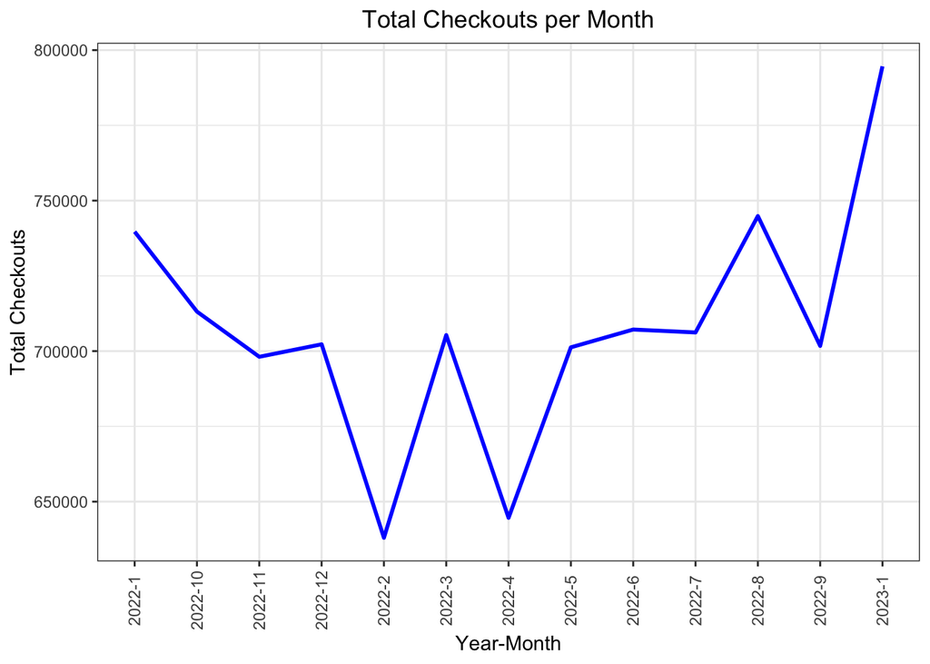

```r
source("chart2.R")
chart2
```

I include this chart to show the overall checkouts from Jan 2022 through Jan 2023. This is important for us to gain a basic view of how checkouts varies through time generally so that we can better understand how each material performs relative to overall pattern.

This plots shows that the checkouts have no clear increasing or decreasing pattern. The chart has two clear troughs, one in February 2022 and another in April 2022. After April, the total number of checkouts shows an overall upward trend.

### Second Trends Over Time Chart

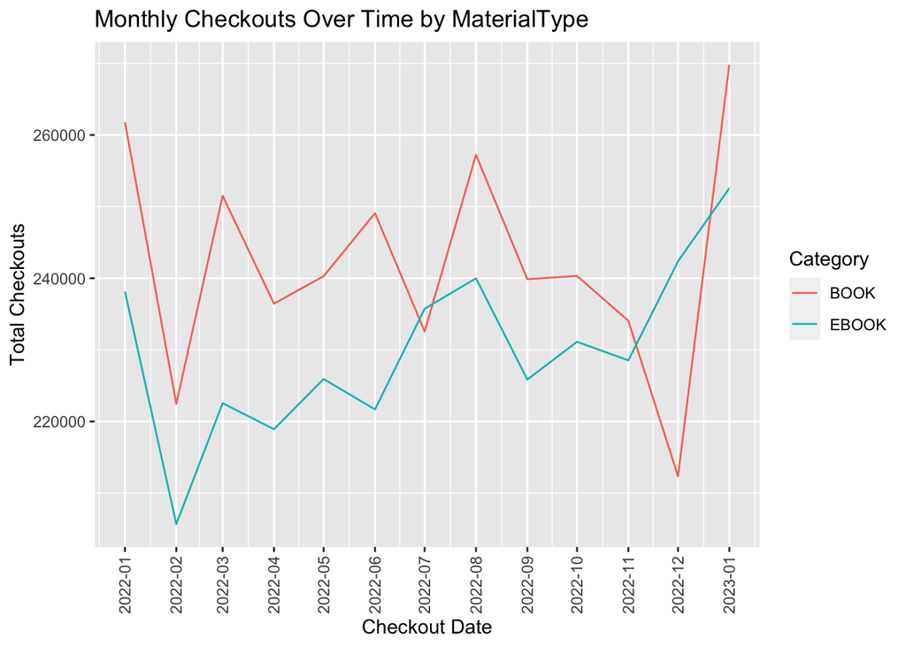

```r
source("chart1.R")

chart1
```

I included the line chart to analyze the monthly checkout patterns of books and ebooks in the library’s collection over time. By visualizing the data with a line chart, we can easily identify trends and patterns that may not be immediately apparent from just looking at the raw data.

### Pie chart

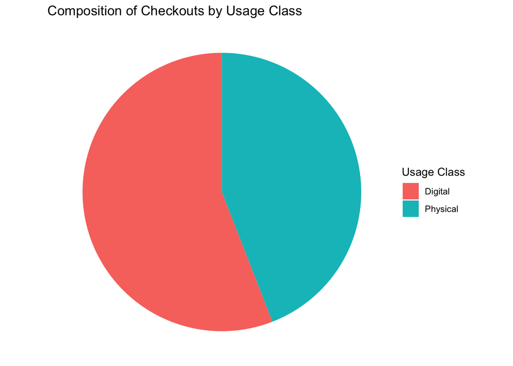

```r
source("chart3.R")

chart3
```

I choose to make a pie chart to see the composition of checkouts. By using pie chart, it is easier for us to see how the checkouts are formed and how much percent does digital or physical checkout take part in.

This pie chart shows that digital checkout is significantly larger than physical checkouts.